# Homework 2

Ella Marrero, David Morales, Brandon Powell, Joon Chae

4/14/2021

# Data

We will be examining data about house sales, which include a number of variables about house price/mortgage, distabce from airports, and more. See this [Codebook](https://codowd.com/bigdata/hw/hw2/homes2004code.txt) for interpretation of all variables used.

## Tidy/Re-code Data

First, we will re-code and tidy the data from characters to binaries and factored levels.

```r
# Determine the # of levels/unique obs for each var
lapply(homes,function(x) length(unique(x)))
# > Lots of vars with only 2 levels (Y/N, T/F)
```

```r
#For each var, find uniq values, sort (if 2 uniq obs),
#recode as binary
for (i in 1:ncol(homes)) {
  uniques = unique(homes[[i]])
  uniques = sort(uniques)
  if (length(uniques) != 2) next
  if (uniques[1] == "N" & uniques[2] == "Y") {
    homes[[i]] = (homes[[i]] == "Y")
  } else { #Otherwise, print problem columns
    print(i)
    print(uniques)
  }
}
```

```
## [1] 11
## [1] "bad"  "good"
## [1] 12
## [1] "bad"  "good"
## [1] 21
## [1] "rural" "urban"
## [1] 27
## [1] "other"     "prev home"
```

Now that we’ve recoded the Y/N variables as binaries, lets look at the misbehaving columns to see if we need to do anything else.

```r
colnames(homes)[c(11,12,21,27)]
```

[output not shown]

They seem to be a mix of things, which aren’t all that cleanly converted into binaries. To deal with this, we will re-code all character vectors with more than 2 values (e.g. State) or the variables that didn’t cleanly covert into factors.

```r
# In the homes data, look "across" columns and change ("mutate") the ones that are characters (is.character) into factors ("as.factor")
homes = homes %>% mutate(across(where(is.character),as.factor))
```

# Questions

## Q1 - Regression

First, we will regress log(price) against all the variables except mortgage (AMMRT) and ETRANS.

```r
# create model
mod1 <- glm(log(LPRICE) ~ . -AMMORT -ETRANS, data = homes)
# calculate R^2
get_R <- function(lmod){
  lsumm = summary(lmod)
  Rsquared = 1 - (lsumm$deviance/lsumm$null.deviance)
  Rsquared
}
```

For this regression, we get an $R^2$ value of 0.4472979 with 41 coefficients (including the intercept).

## Q2 - FDR, variable selection

Next, we will re-run the regression with just the variables that are significant at a 5% FDR (h). If a factor has some significant levels, keep the entire factor in. What is the new $R^2$? What happened with the $R^2$? Why? (2 sentences total)

```r
# generate FDR cutoff p-value for data
q = 0.05 # set rate at 5%

pvals <- summary(mod1)$coefficients[,4]

FDR_thresh <- tibble(pvals)%>%
  select(pvals)%>%# from model p-values,
  mutate(k = min_rank(pvals)) %>% #sort by rank
  filter(pvals <= (q*k/n()))%>% # for those <= qk/K
  summarise(alpha = max(pvals))%>% # get max
  as.numeric()

# Get names of vars to be cutoff
varnames <- variable.names(mod1)
bad_names <- varnames[as.numeric(pvals) > FDR_thresh]
bad_names
```

```
## [1] "NUNITS"  "STATECO" "STATECT" "BEDRMS"
```

```r
# New Data frame without cut vars
sig_homes <- homes[!(names(homes) %in% bad_names)]
mod2 <- glm(log(LPRICE) ~ . -AMMORT -ETRANS, data = sig_homes)
rdif <- get_R(mod1) - get_R(mod2)
```

The $R^2$ for this new regression is 0.4471949 being less than the first model by 1.0306764^{-4}. This change comes from gaining additional residual deviance that was previously explained by the less significant variables which were cut by the 5% FDR.

## Q3 - Logit

Now, we will make a binary variable indicating whether or not buyers had at least a 20% down payment (i.e., mortgage value is less than 80% of the price) to do some classification with logit models.

First, we will fit a logit to predict this binary using all variables except for mortgage (AMMORT) and price (LPRICE), as we used those to create the binary itself.

```r
# add binary classification for mortgage
homes <- homes %>%
  mutate(dp20 = as.numeric((AMMORT/LPRICE) <= 0.8))

# generate model
mod3 <- glm(dp20 ~ (. -AMMORT -LPRICE), data = homes, family = binomial)

# number of coefficients (including intercept)
varlen3 <- length(variable.names(mod3))
```

Then we will fit the same model, but with all variables interacted (once) with each other.

```r
# generate model
mod4 <- glm(dp20 ~ (. -AMMORT -LPRICE)^2, data = homes, family = binomial)

# number of coefficients (including intercept)
varlen4 <- length(variable.names(mod4))
cat("Coefficients in model (including intercept):", varlen4)
```

```
## Coefficients in model (including intercept): 787
```

The second model has 745 more coefficients.

```r
# calculate R^2 for both models
rvals <- c(get_R(mod3), get_R(mod4))
```

| Logit Model | R Squared |
| --- | --- |
| Without Interactions | 0.1038013 |
| With Interactions | 0.1619313 |

The model with interactions has a higher $R^2$, and thus at this stage, we would prefer it to the model without interactions. However, we would be wary, as this model is quite complex and may be over-fitting the data.

## Q4 - Out of Sample A

Now, we will estimate the same model as in Q1, but using only data where ETRANS is TRUE.

First, we will split the data into subsets where ETRANS is TRUE (training) and ETRANS is FALSE (testing).

```r
# Split data into training and testing (based on ETRANS is T/F)
etran_t <- homes %>% filter(ETRANS)
etran_f <- homes %>%  filter(!ETRANS)

# check sample size for split data
cat("TRAIN: ", nrow(etran_t))
```

```
## TRAIN:  1246
```

```r
cat("\nTEST: ", nrow(etran_f))
```

```
##
## TEST:  14319
```

Then we will train the model on the training data (ETRANS = T), and see how well it performs by making predictions using our testing data (ETRANS = F). Show the out-of-sample fitted vs real outcome plot (hint: it may be helpful to add both a 45 degree line, and the best fit line). Describe what happened here (max 2 sentences, variable codebook may help you).

```r
# train model on training data, ETRANS = T
mod5 <- glm(log(LPRICE) ~ . -AMMORT -ETRANS, data = etran_t)

# predict using testing data, ETRANS = F
etran_f$predictions <- predict(mod5, newdata = etran_f)
```

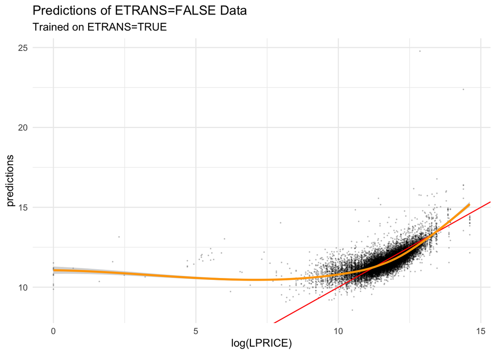

```r
ggplot(etran_f, aes(x = log(LPRICE), y = predictions))+
  geom_point(size = 0.1, alpha = 0.2)+
  geom_abline(intercept = c(0,0), slope = 1, color =  'red')+

  geom_smooth(method = "loess", color = "orange")+
  labs(title = 'Predictions of ETRANS=FALSE Data', subtitle = 'Trained on ETRANS=TRUE')+
  theme_minimal()
```

The model seems to actually fit the data relatively well where log price is between about 12 and 14, but has a decent number of outliers and huge amount of variance in the residuals, leaving this model somewhat tenuous.

Predictions fall apart at large and small log prices. ETRANS indicated if a house was within an airport or 4-lane highway within a half a block. These houses tend to be less expensive. By training only on ETRANS = T, we are training the model on cheaper houses, so when the houses are more expensive (as evident in the graph), the model performs more poorly.

## Q5 - Out of Sample B

```r
sig_homes <- sig_homes %>%
  mutate(dp20 = as.numeric((AMMORT/LPRICE) <= 0.8))
set.seed(123)
holdout <- sample.int(nrow(sig_homes), 1000)
training <- sig_homes[-holdout,]
testing <- sig_homes[holdout,]
```

Then, we will re-fit our models from Q3 using the training data.

```r
# train on testing data, 1000 randomly selected observations
mod6 <- glm(dp20 ~ (. -AMMORT -LPRICE), data = training, family = binomial)
mod7 <- glm(dp20 ~ (. -AMMORT -LPRICE)^2, data = training, family = binomial)
```

With these newly-fitted models, we will then make predictions for the testing data (holdout sample), using each model. We will assess the accuracy of these models by calculating the mean squared errors for each of the models out of sample (using the prediction error for each observation in the testing data).

```r
pred6 <- predict(mod6, newdata = testing, type = 'response')
pred7 <- predict(mod7, newdata = testing, type = 'response')
test_vals <- testing$dp20

# calculate MSE for both models
get_mse <- function(ypred, ytrue){
  pe <- ytrue - ypred # subtract actual from predicted
  mean(pe**2) # mean square of deviance
}
mse6 <- get_mse(pred6, test_vals)
mse7 <- get_mse(pred7, test_vals)
```

The MSE for each model is:

| Logit Model | MSE |
| --- | --- |
| Without Interactions | 0.1986087 |
| With Interactions | 0.2073997 |

At this stage, we would prefer the model without interactions as it has a much more manageable number of coefficients as well as marginally smaller MSE.

The model with interactions is more likely to over fit here as the number of coefficients is extremely high and it performs worse on OOS predictions.